# Reviewing Rake Abundances

Mike Verhoeven

2020-11-19

This code will clean the relative rake density data from the whole PI dataset

# Clean Up Rake Density Data?

Presence/absence use of these data has been a sound apporach, and has been how these data have been used to-date. But the relative rake abundances contain useful, point-level dat about species specific biomass (even if they are an imperfect, subjective data type).

On 30 Oct 2020 Mike Verhoeven, Dan Larkin, Shyam Thomas, and Jake Walsh had a meeting to discuss how to clean up rake abundance data, and how to handle some of the quirkiness of the datasets.

The first issue we tackled was how to infer which ranking system a surveyor was using. This issue arises because different surveyors use ranking systems that vary (most commonly for veg on rake a scale of 1-3, 1-4, or 1-5 is used) but they do not include in their data contributions any indication of what sclae they are using. We decided that we could reasonably infer the scale used by revieing the max value recorded in a given year from each surveyor. While we are finishing up cleaning our surveyor data, we will use the data contributor instead. Thus, for each contributor-year of surveys we will set the scale they used based on the max rake density observed.

The second issue we tackled was how to stretch each of these different rake density scales to fit on the same scale. To do this, we have decided to convert the all rake density data to be a 1,2,3 scale from 1-4 and 1-5. This is done by setting endpoints of all scales to 1 and 3, then lumping all mid- values into the category of 2. We feel that this fits the truncation of how much biomass can be picked up on a rake (each scale’s max values are a “fully covered” rake), and that all scales define their lowest category (1) as something along the lines of “a single fragment or very small amount of a species picked up on the rake.”

Here we implement these changes and we review the N of presence absence versus rel rake density surveys.

##’Load Workspace

```r
# load libraries ----------------------------------------------------------

library(data.table)
library(ggplot2)
library(gridExtra)


# load in data ------------------------------------------------------------

king <- fread(file = "data/output/plant_surveys_mn.csv")

# grab records with rake abundance data ----------------------------------------
```

## Review dataset and issue in question

```r
names(king)
```

```
##  [1] "DOWLKNUM"                "LAKE_NAME"
##  [3] "DATASOURCE"              "SURVEY_DATE"
##  [5] "STA_NBR"                 "DEPTH_FT"
##  [7] "NO_VEG_FOUND"            "REL_ABUND"
##  [9] "VEG_REL_ABUNDANCE_DESCR" "SUBSTRATE"
## [11] "SURVEYOR"                "TAXON"
## [13] "SURVEY_ID_DATASOURCE"    "SAMPLE_NOTES"
## [15] "SURFACE_GROWTH"          "POINT_LVL_SECCHI"
## [17] "X"                       "Y"
## [19] "NORTHING"                "EASTING"
## [21] "latitude"                "longitude"
## [23] "UTMX"                    "UTMY"
## [25] "SURVEY_ID"               "POINT_ID"
## [27] "OBS_ID"
```

```r
#how many total surveys in the dataset?
king[ , .N , SURVEY_ID] # all of the surveys can be considered "presence/absence"
```

```
##       SURVEY_ID   N
##    1:         1  63
##    2:         2 126
##    3:         3 160
##    4:         4 147
##    5:         5 118
##   ---
## 3304:      3304  31
## 3305:      3305 109
## 3306:      3306 175
## 3307:      3307 328
## 3308:      3308   8
```

```r
#how many surveys submitted seem to be rel rake abundance surveys?
king[!is.na(REL_ABUND) , .N , SURVEY_ID] # 1122 surveys
```

```
##       SURVEY_ID   N
##    1:       253 678
##    2:       254 230
##    3:       255 213
##    4:       256 121
##    5:       257 281
##   ---
## 1118:      3260 100
## 1119:      3261  73
## 1120:      3264 312
## 1121:      3265 409
## 1122:      3266 448
```

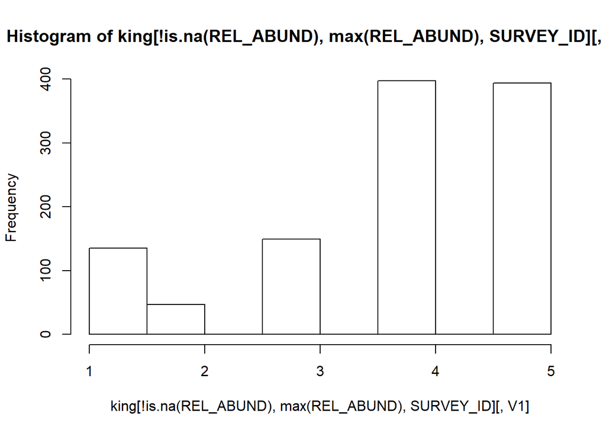

```r
#what is the distribution of max values observed in those surveys?
#by survey
hist(king[!is.na(REL_ABUND) , max(REL_ABUND) , SURVEY_ID][,V1])
```

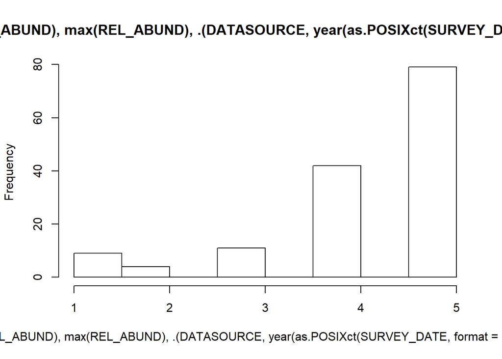

```r
# and by contibutor-era
hist(king[!is.na(REL_ABUND) , max(REL_ABUND) , .(DATASOURCE,year(as.POSIXct(SURVEY_DATE, format = "$Y-$m-$d")))][,V1])
```

```r
#append contrib-era-max field to data (prep for later sorting and manip)
king[!is.na(REL_ABUND)  , CONTERAMAXRAKE:= max(REL_ABUND) ,
     .(DATASOURCE,year(as.POSIXct(SURVEY_DATE, format = "$Y-$m-$d"))) # contributor-era
     ]

#now plot these by survey:
king[!is.na(REL_ABUND)  , mean(CONTERAMAXRAKE) , SURVEY_ID]
```

```
##       SURVEY_ID V1
##    1:       253  4
##    2:       254  5
##    3:       255  5
##    4:       256  5
##    5:       257  5
##   ---
## 1118:      3260  3
## 1119:      3261  3
## 1120:      3264  4
## 1121:      3265  5
## 1122:      3266  4
```

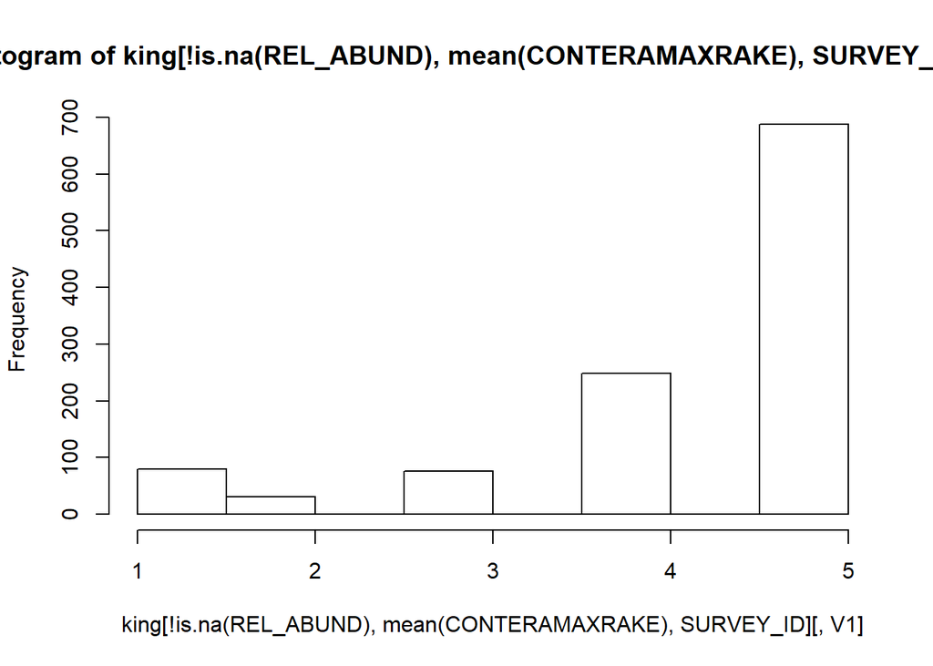

```r
hist(king[!is.na(REL_ABUND)  , mean(CONTERAMAXRAKE) , SURVEY_ID][,V1])
```

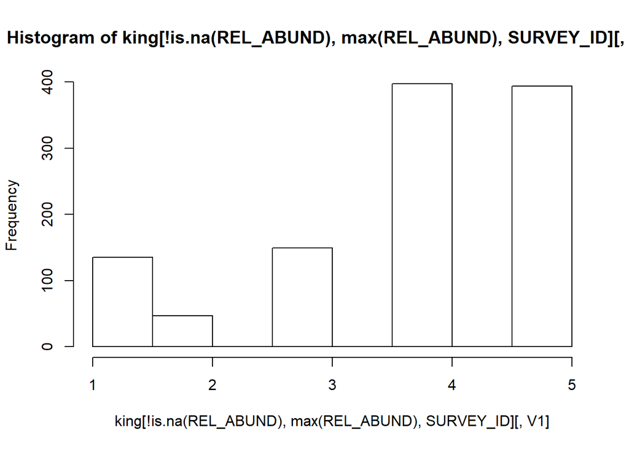

```r
#and for comparison, this is what we would have said is we'd used max vals w/in surveys:
hist(king[!is.na(REL_ABUND)  , max(REL_ABUND) , SURVEY_ID][,V1])
```

## Determining the rake scale used

Contributor-era max and and survey max produce different results.

We’ll compile these surveys both ways, noting that contributor-era max rake densities suffer from the contributor not always being the surveyor. At the end, we’ll review what each approach gave us and pick one.

## Survey level max (method 1)

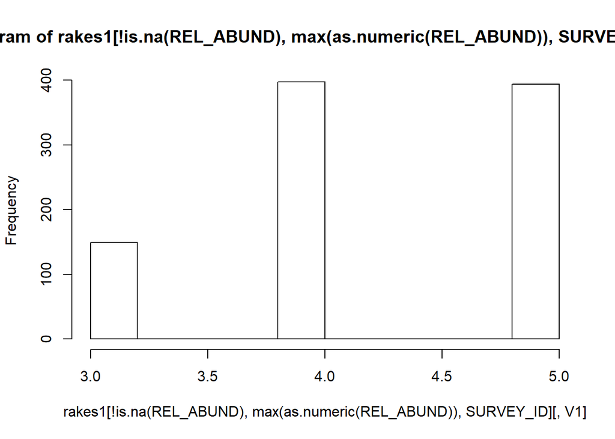

```r
# implement changes by survey -------------------------------------------

#drop surveys with max vals of 1s and 1-2s
rakes1 <- king[SURVEY_ID %in% king[!is.na(REL_ABUND)  , max(REL_ABUND) , SURVEY_ID  ][V1 %in% c(3,4,5),SURVEY_ID], ]

#check that we've dropped the 1's and 2's
hist(rakes1[!is.na(REL_ABUND)  , max(as.numeric(REL_ABUND)) , SURVEY_ID  ][,V1])
```

```r
#how many surveys in these categories?
rakes1[  , .N  , SURVEY_ID]
```

```
##      SURVEY_ID    N
##   1:       253  678
##   2:       254  298
##   3:       255  268
##   4:       256  202
##   5:       257  324
##  ---
## 936:      3254 1103
## 937:      3260  198
## 938:      3264  340
## 939:      3265  432
## 940:      3266  520
```

[figure not shown]

```r
#Now shift/ realign data per discussion above

#1-4 survey shifted to 1-3
rakes1[SURVEY_ID %in% king[!is.na(REL_ABUND)  , max(REL_ABUND) , SURVEY_ID ][V1 == 4,SURVEY_ID] &
          REL_ABUND == 3 , REL_ABUND := 2 ]
rakes1[SURVEY_ID %in% king[!is.na(REL_ABUND)  , max(REL_ABUND) , SURVEY_ID ][V1 == 4,SURVEY_ID] &
         REL_ABUND == 4 , REL_ABUND := 3 ]

#1-5 surveys shifted to 1-3
rakes1[SURVEY_ID %in% king[!is.na(REL_ABUND)  , max(REL_ABUND) , SURVEY_ID ][V1 == 5,SURVEY_ID] &
         (REL_ABUND == 3 |REL_ABUND == 4) , REL_ABUND := 2 ]
rakes1[SURVEY_ID %in% king[!is.na(REL_ABUND)  , max(REL_ABUND) , SURVEY_ID ][V1 == 5,SURVEY_ID] &
         REL_ABUND == 5 , REL_ABUND := 3 ]

#check that the max vals are all 3's
hist(rakes1[ !is.na(REL_ABUND) , max(REL_ABUND) , SURVEY_ID  ][,V1])
```

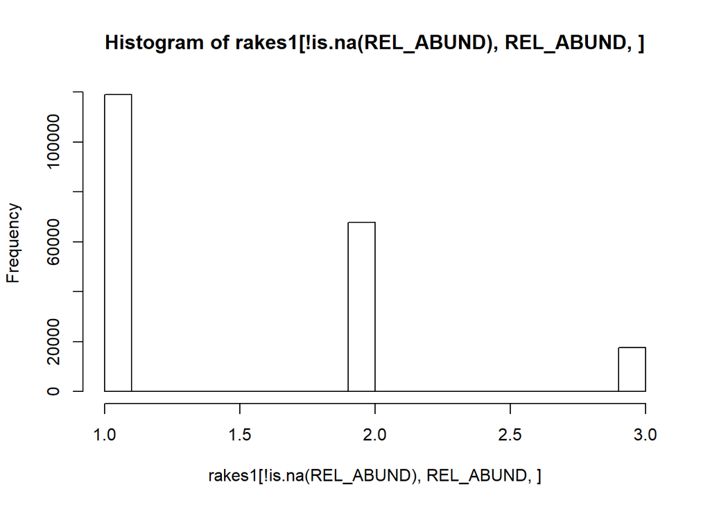

```r
#and all data are distributed in 1-3 rake density framework
hist(rakes1[ !is.na(REL_ABUND) , REL_ABUND ,  ])
```

```r
# count the number of surveys we've got
rakes1[ , .N , SURVEY_ID ] # N points per survey (includes NA's--points where no species were observed)
```

```
##      SURVEY_ID    N
##   1:       253  678
##   2:       254  298
##   3:       255  268
##   4:       256  202
##   5:       257  324
##  ---
## 936:      3254 1103
## 937:      3260  198
## 938:      3264  340
## 939:      3265  432
## 940:      3266  520
```

```r
# do changes by contributor-era -------------------------------------------
```

## Contributor-era maximums used to det rake scale (method 2)

```r
#how many contributor-eras and whats max rake dens for each?
king[!is.na(REL_ABUND)  , max(REL_ABUND) ,
       .(DATASOURCE,year(as.POSIXct(SURVEY_DATE, format = "$Y-$m-$d")))
       ]
```

```
##              DATASOURCE year V1
##   1:      James Johnson 2017  4
##   2:      James Johnson 2015  5
##   3:             newman 2011  5
##   4:             newman 2012  5
##   5:             newman 2013  5
##  ---
## 141:         Meg Rattei 2013  4
## 142:         Meg Rattei 2012  4
## 143:         Meg Rattei 2010  5
## 144: Andrea Prichard_19 2011  5
## 145:     Eric Fieldseth 2016  3
```

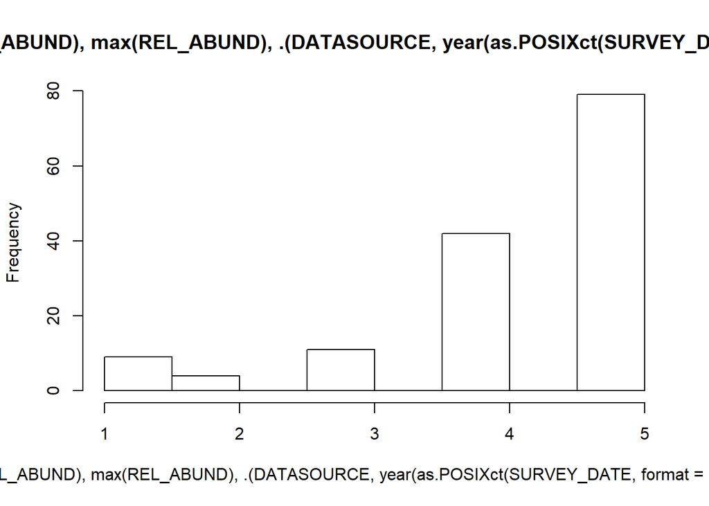

```r
#hist max vals
hist(king[!is.na(REL_ABUND)  , max(REL_ABUND) ,
          .(DATASOURCE,year(as.POSIXct(SURVEY_DATE, format = "$Y-$m-$d")))
          ][,V1])
```

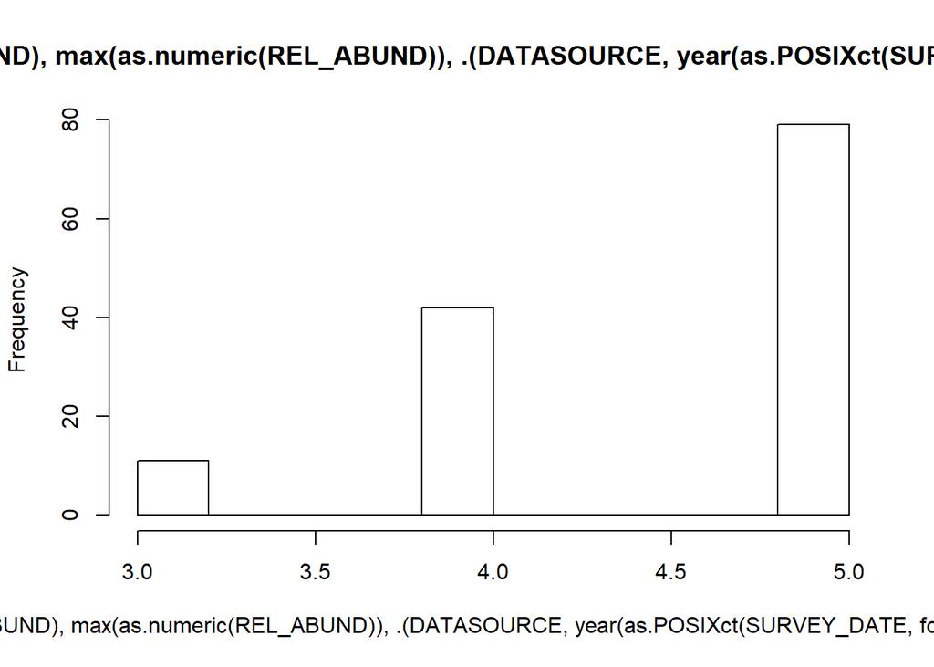

```r
#drop surveys with max vals of 1s and 1-2s
rakes2 <- king[SURVEY_ID %in% king[!is.na(REL_ABUND), mean(CONTERAMAXRAKE) , SURVEY_ID][V1 %in% c(3,4,5),SURVEY_ID], ]

#check that we've dropped the 1's and 2's
hist(rakes2[!is.na(REL_ABUND)  , max(as.numeric(REL_ABUND)) ,
            .(DATASOURCE,year(as.POSIXct(SURVEY_DATE, format = "$Y-$m-$d")))][,V1])
```

```r
#how many surveys in these categories?
rakes2[  , .N  , SURVEY_ID]
```

```
##       SURVEY_ID   N
##    1:       253 678
##    2:       254 298
##    3:       255 268
##    4:       256 202
##    5:       257 324
##   ---
## 1007:      3260 198
## 1008:      3261 173
## 1009:      3264 340
## 1010:      3265 432
## 1011:      3266 520
```

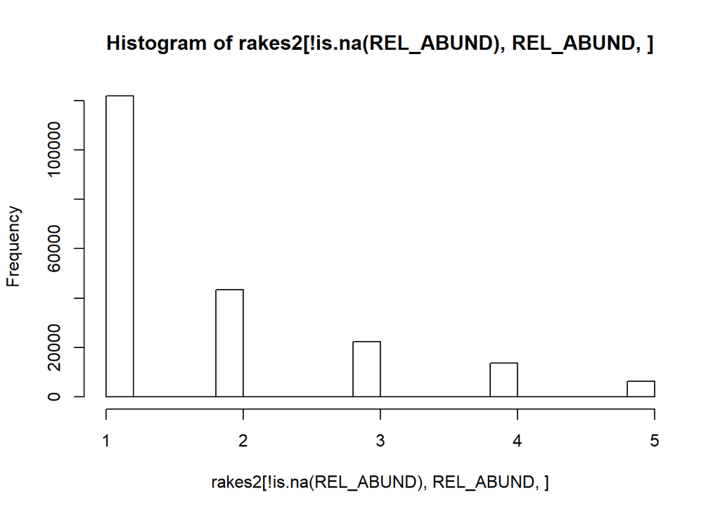

```r
#distribution of densities:
hist(rakes2[!is.na(REL_ABUND), REL_ABUND, ])
```

[figure not shown]

```r
#Now shift/ realign data per discussion at top of code

#1-4 survey shifted to 1-3
rakes2[SURVEY_ID %in% king[!is.na(REL_ABUND)  , mean(CONTERAMAXRAKE) , SURVEY_ID ][V1 == 4,SURVEY_ID] &
         REL_ABUND == 3 , REL_ABUND := 2 ]
rakes2[SURVEY_ID %in% king[!is.na(REL_ABUND)  , mean(CONTERAMAXRAKE) , SURVEY_ID ][V1 == 4,SURVEY_ID] &
         REL_ABUND == 4 , REL_ABUND := 3 ]

#1-5 surveys shifted to 1-3
rakes2[SURVEY_ID %in% king[!is.na(REL_ABUND)  , mean(CONTERAMAXRAKE) , SURVEY_ID ][V1 == 5,SURVEY_ID] &
         (REL_ABUND == 3 |REL_ABUND == 4) , REL_ABUND := 2 ]
rakes2[SURVEY_ID %in% king[!is.na(REL_ABUND)  , mean(CONTERAMAXRAKE) , SURVEY_ID ][V1 == 5,SURVEY_ID] &
         REL_ABUND == 5 , REL_ABUND := 3 ]

#check that the max vals are all 3's in each contributor-era
hist(rakes2[ !is.na(REL_ABUND) , max(REL_ABUND) , .(DATASOURCE,year(as.POSIXct(SURVEY_DATE, format = "$Y-$m-$d")))  ][,V1])
```

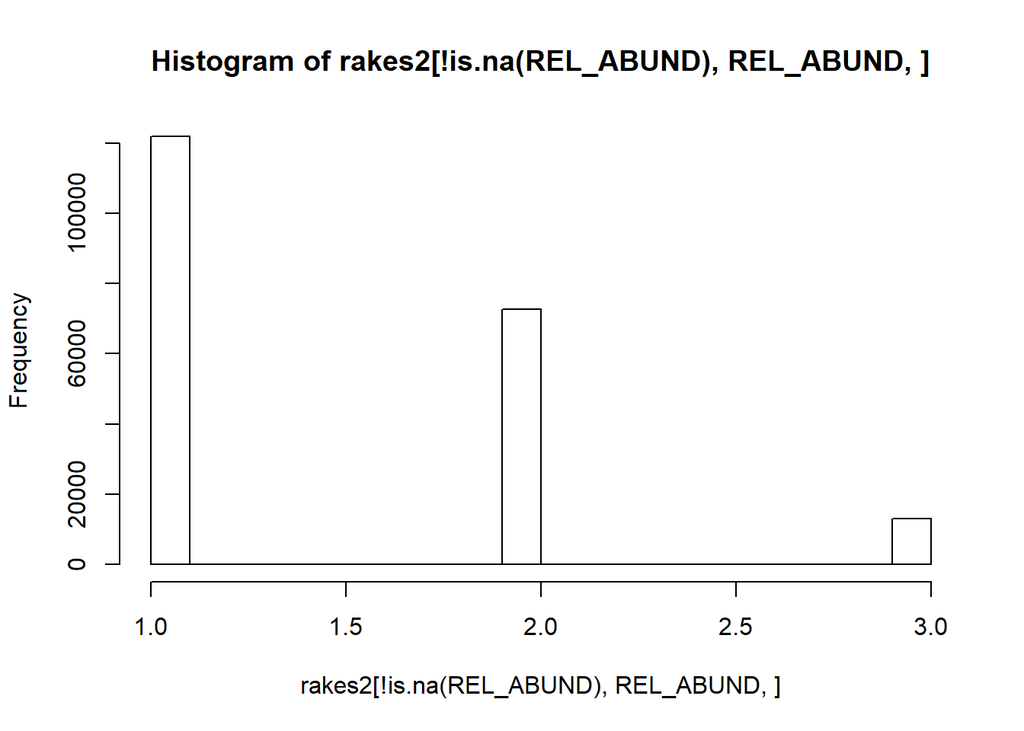

```r
#and all data are distributed in 1-3 rake density framework
hist(rakes2[ !is.na(REL_ABUND) , REL_ABUND ,  ])
```

```r
# count the number of surveys we've got
rakes2[ , .N , SURVEY_ID ] # N points per survey (includes NA's--points where no species were observed)
```

```
##       SURVEY_ID   N
##    1:       253 678
##    2:       254 298
##    3:       255 268
##    4:       256 202
##    5:       257 324
##   ---
## 1007:      3260 198
## 1008:      3261 173
## 1009:      3264 340
## 1010:      3265 432
## 1011:      3266 520
```

# Plots to visualize data cleaning outcomes

We’ve implemented our changes in multiple ways. Let’s throw up a few plots to visualize what we’ve done.

```r
#choose a cutoff N for samples to warrant inclusion (by species)

#survey points sampled by year
king_points <- ggplot(king[ , .N , .(SURVEY_DATE, SURVEY_ID ,POINT_ID)], aes(year(as.POSIXct(SURVEY_DATE, format = "$Y-$m-$d"))))+
  geom_histogram(binwidth = 1, color = "gray", fill = 1 )+
  xlab("Year")+
  ylab("N points sampled")+
  labs(title = "Pres/Abs points sampled per year")

#surveys conducted by year
king_surveys <- ggplot(king[ , .N , .(SURVEY_DATE, SURVEY_ID)], aes(year(as.POSIXct(SURVEY_DATE, format = "$Y-$m-$d"))))+
  geom_histogram(binwidth = 1, color = "gray", fill = 1 )+
  xlab("Year")+
  ylab("N surveys")+
  labs(title = "Pres/Abs surveys conducted per year")

#rake density survey points sampled by year
rd_points_method1 <- ggplot(rakes1[ , .N , .(SURVEY_DATE, SURVEY_ID ,POINT_ID)], aes(year(as.POSIXct(SURVEY_DATE, format = "$Y-$m-$d"))))+
  geom_histogram(binwidth = 1, color = "gray", fill = 1 )+
  xlab("Year")+
  ylab("N points sampled")+
  labs(title = "Rake points sampled per year (method1)")

#rake density survey points sampled by year
rd_points_method2 <- ggplot(rakes2[ , .N , .(SURVEY_DATE, SURVEY_ID ,POINT_ID)], aes(year(as.POSIXct(SURVEY_DATE, format = "$Y-$m-$d"))))+
  geom_histogram(binwidth = 1, color = "gray", fill = 1 )+
  xlab("Year")+
  ylab("N points sampled")+
  labs(title = "Rake points sampled per year (method2)")

#rake surveys conducted by year
rd_surveys_method1 <- ggplot(rakes1[ , .N , .(SURVEY_DATE, SURVEY_ID)], aes(year(as.POSIXct(SURVEY_DATE, format = "$Y-$m-$d"))))+
  geom_histogram(binwidth = 1, color = "gray", fill = 1 )+
  xlab("Year")+
  ylab("N surveys")+
  labs(title = "rake surveys conducted per year (method1)")

#rake surveys conducted by year
rd_surveys_method2 <- ggplot(rakes2[ , .N , .(SURVEY_DATE, SURVEY_ID)], aes(year(as.POSIXct(SURVEY_DATE, format = "$Y-$m-$d"))))+
  geom_histogram(binwidth = 1, color = "gray", fill = 1 )+
  xlab("Year")+
  ylab("N surveys")+
  labs(title = "rake surveys conducted per year (method2)")
```

## Sample sizes

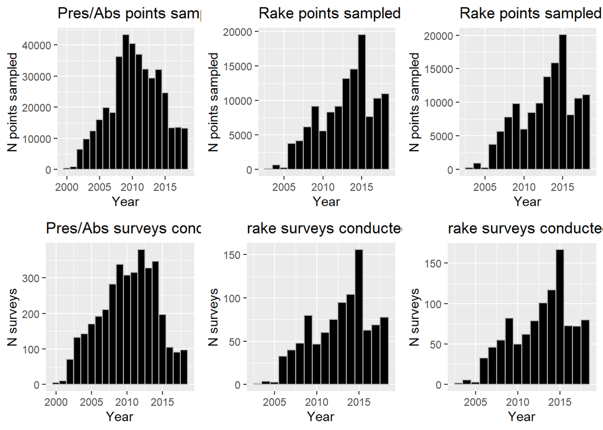

```r
grid.arrange(king_points,rd_points_method1, rd_points_method2,king_surveys,rd_surveys_method1, rd_surveys_method2, ncol = 3, nrow = 2)
```

```r
#distribution of rake densities

uncorrected_desities <-
  ggplot( king[!is.na(REL_ABUND), ], aes(REL_ABUND))+
  geom_histogram(binwidth = 1, color = "gray", fill = 1 )+
  ylim(c(0,160000))+
  labs(title = "uncorrected")

# uncorrected_desities_3scale_contrib <-
#   ggplot( king[!is.na(REL_ABUND) & CONTERAMAXRAKE == 3, ], aes(REL_ABUND))+
#   geom_histogram(binwidth = 1, color = "gray", fill = 1 )+
#   ylim(c(0,11000))+
#   labs(title = "uncorrected_scale1-3_method2")

uncorrected_desities_3scale_survey <-
  ggplot( king[!is.na(REL_ABUND) &
                 SURVEY_ID %in% king[!is.na(REL_ABUND)  , max(REL_ABUND) , SURVEY_ID ][V1 == 3, SURVEY_ID ], ,
               ],
               aes(REL_ABUND))+
  geom_histogram(binwidth = 1, color = "gray", fill = 1 )+
  ylim(c(0,18000))+
  labs(title = "uncorrected_scale1-3surveys")

corrected_method1 <-
  ggplot( rakes1[!is.na(REL_ABUND), ], aes(REL_ABUND))+
  geom_histogram(binwidth = 1, color = "gray", fill = 1 )+
  ylim(c(0,160000))+
  labs(title = "method1")

corrected_method2 <-
  ggplot( rakes2[!is.na(REL_ABUND), ], aes(REL_ABUND))+
  geom_histogram(binwidth = 1, color = "gray", fill = 1 )+
  ylim(c(0,160000))+
  labs(title = "method2")
```

## Density distributions

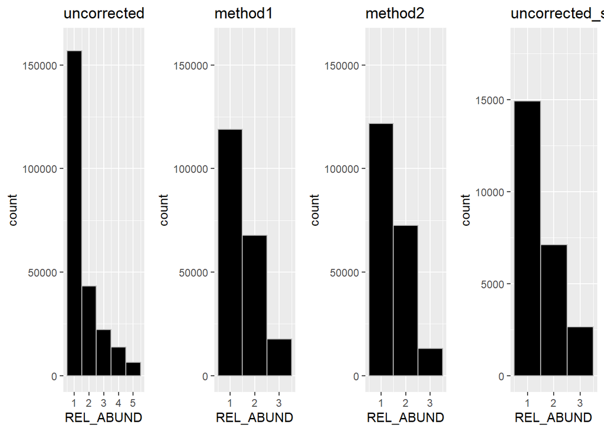

```r
grid.arrange(uncorrected_desities,corrected_method1,corrected_method2,uncorrected_desities_3scale_survey, ncol = 4)
```

# Which method of determining max rake density was best?

Here we can see that the use of max values within a survey to determine rake density scales are a slightly better match to those surveys originally surveyed on a 1-3 scale. I made this determination by comparing the ratio of 1:2:3 in each of method 1, method 2, and originally submitted as 1-3 surveys. We could or should use a statistical test to evaluate this more empirically– but I’m not certain I know what test would serve us best.

Given this conclusion (method 1 is better of the two options), let’s export the dataset for use in other projects:

```r
str(rakes1)
```

```
## Classes 'data.table' and 'data.frame':   270793 obs. of  28 variables:
##  $ DOWLKNUM               : chr  "10000100" "10000100" "10000100" "10000100" ...
##  $ LAKE_NAME              : chr  "ricemarsh" "ricemarsh" "ricemarsh" "ricemarsh" ...
##  $ DATASOURCE             : chr  "James Johnson" "James Johnson" "James Johnson" "James Johnson" ...
##  $ SURVEY_DATE            : IDate, format: "2017-08-07" "2017-08-07" ...
##  $ STA_NBR                : chr  "1" "1" "1" "1" ...
##  $ DEPTH_FT               : num  1.64 1.64 1.64 1.64 1.64 ...
##  $ NO_VEG_FOUND           : logi  FALSE FALSE FALSE FALSE FALSE FALSE ...
##  $ REL_ABUND              : int  2 1 1 1 1 2 1 1 1 1 ...
##  $ VEG_REL_ABUNDANCE_DESCR: chr  "" "" "" "" ...
##  $ SUBSTRATE              : chr  "" "" "" "" ...
##  $ SURVEYOR               : chr  "" "" "" "" ...
##  $ TAXON                  : chr  "Ceratophyllum demersum" "Lemna minor" "Nymphaea odorata" "Spirodela polyrhiza" ...
##  $ SURVEY_ID_DATASOURCE   : chr  "1000" "1000" "1000" "1000" ...
##  $ SAMPLE_NOTES           : chr  ";" ";" ";" ";" ...
```

[output cut: 16 more lines]

```r
# write.csv(rakes1, file = "data/output/rake_abund_surveys_mn.csv" )
```